# Laboratorio 5

Author

Joshua Cervantes

Published

Invalid Date

```python
# Se procede a importar los paquetes
import pandas as pd
import numpy as np
from cod.ejercicio import ejercicio_1 as ej1
import seaborn as sns
import matplotlib.pyplot as plt
```

# Ejercicio 1

## Notas escolares

```python
df_notas = pd.read_csv("./data/NotasEscolares.csv")
```

Se procede a llamar la clase que programamos

```python
notas_escolares_kmeans = ej1(df_notas.drop(["Estudiante"], axis = 1))
```

### 3 cluster

Hacemos el multistart con 3 clases

```python
notas_ms_3 = notas_escolares_kmeans.kmeans_multistart(3, 1000)
```

```python
notas_ms_3["mejor_inercia"]
```

```
8.159635931538446
```

La mejor inercia es inferior a 9.

```python
notas_ms_3["tau"]
```

```
82.39999999999999
```

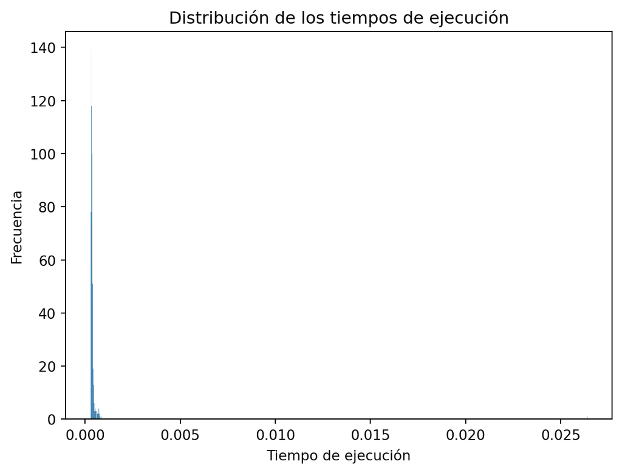

```python
notas_escolares_kmeans.plot_comportamiento_tiempos()
```

Los tiempos se encuentran realmente bajos siendo inferiores al segundo.

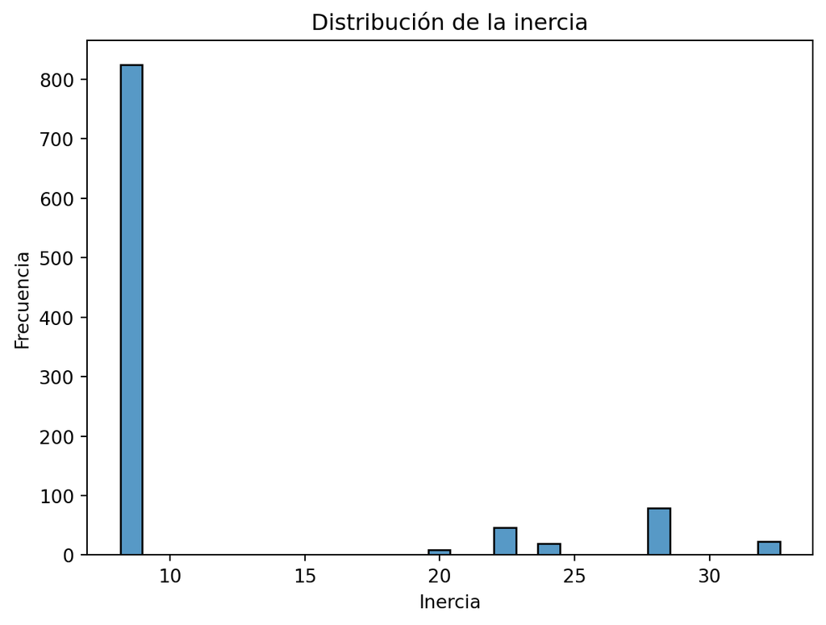

```python
notas_escolares_kmeans.plot_comportamiento_locales()
```

Se puede observar que la inercia en la mayoría de los casos se ubica poder debajo de 10. Aunque hay casos en los que la inercia queda realmente alta.

```python
notas_ms_3["iteraciones_promedio"]
```

```
2.895
```

Se puede obsevar que en esta tabla de datos cada multistart en promedio converge rápidamente.

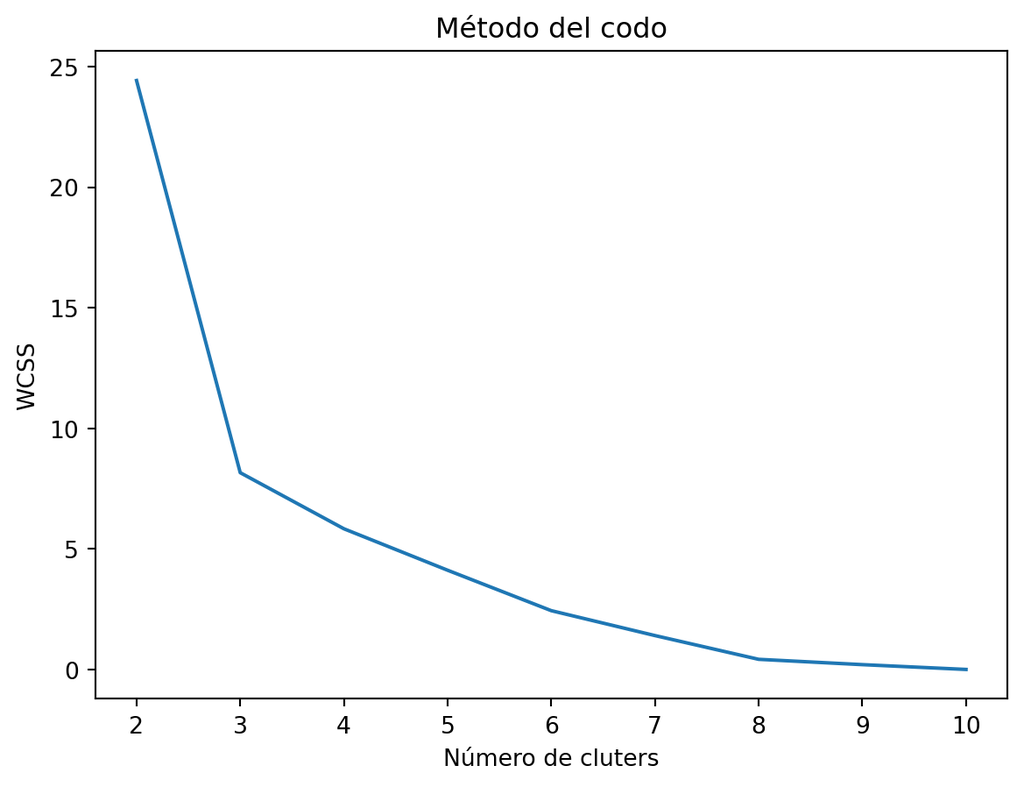

```python
notas_escolares_kmeans.elbow()
```

### 4 cluster

Hacemos el multistart con 4 clases

```python
notas_ms_4 = notas_escolares_kmeans.kmeans_multistart(4, 1000)
```

```python
notas_ms_4["mejor_inercia"]
```

```
5.83348025046322
```

Se puede observar que la inercia obtenida en este caso es inferior al caso anterio como es de esperar dado que a mayor clases la inercia intraclase disminuye.

```python
notas_ms_4["tau"]
```

```
20.9
```

La tasa de atracción en este caso es mucho menor que en el caso anterior esto dado a que existe una mayor cantidad de combinaciones que se pueden hacer.

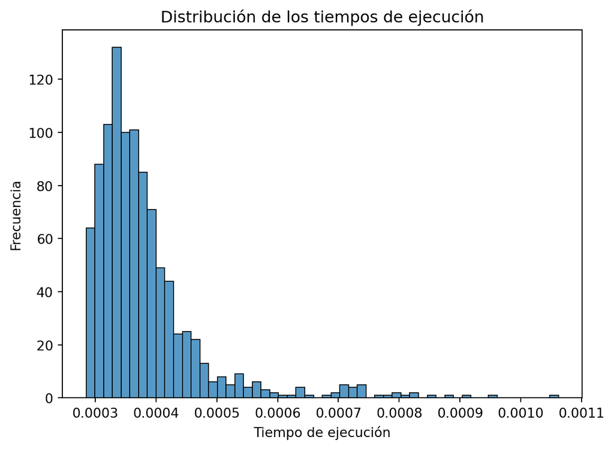

```python
notas_escolares_kmeans.plot_comportamiento_tiempos()
```

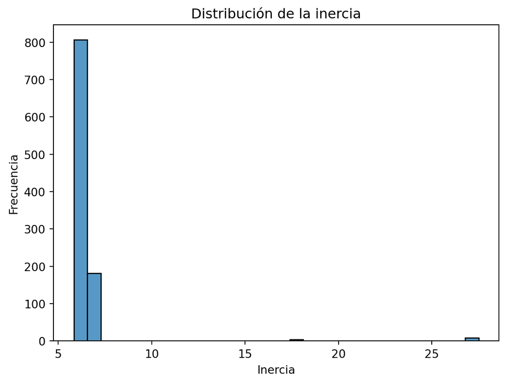

```python
notas_escolares_kmeans.plot_comportamiento_locales()
```

La inercia se comporta muy similar al caso anterior siendo inferior a 10, pero sí se nota que es mucho menor en general.

```python
notas_ms_4["iteraciones_promedio"]
```

```
2.835
```

Se disminuye el número de iteraciones.

## Peces de Amiard

```python
df_peces = pd.read_excel("./data/Amiard.xls", skiprows=1)
```

```python
peces_kmeans = ej1(df_peces.drop(["Pez"], axis = 1))
```

### 3 cluster

Hacemos el multistart con 3 clases

```python
peces_ms_3 = peces_kmeans.kmeans_multistart(3, 1000)
```

```python
peces_ms_3["mejor_inercia"]
```

```
176.8071046788838
```

```python
peces_ms_3["tau"]
```

```
13.900000000000002
```

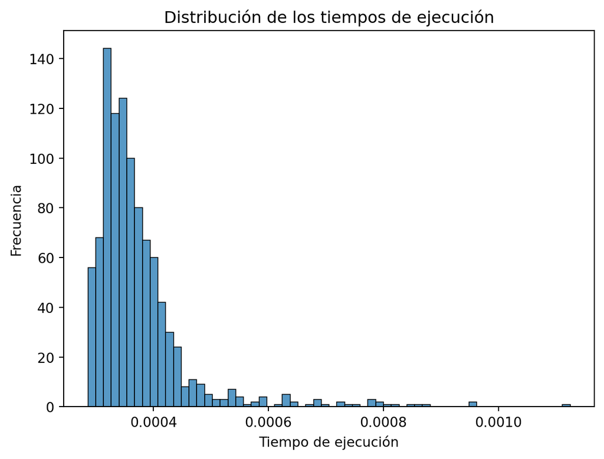

```python
peces_kmeans.plot_comportamiento_tiempos()
```

En este caso se puede observar que los tiempos varian más que en el ejemplo de las notas, esto está relacionado con que hay una mayor cantidad de individuos lo que genera mayor tiempo de ejecución y además afecta el rendimiento del procesador donde pueden haber ejecuciones más prolongadas.

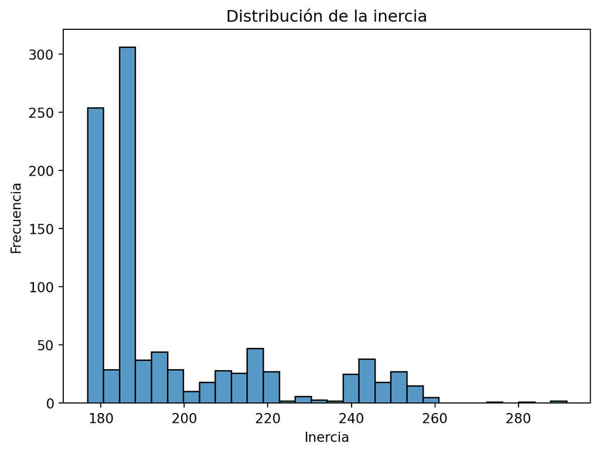

```python
peces_kmeans.plot_comportamiento_locales()
```

En este caso también se ubica una mayor variabilidad en la distirbución de las inercias. Se observa que existen claramente valores los cuales se repiten más alrededor de 180 y 190.

```python
peces_ms_3["iteraciones_promedio"]
```

```
3.726
```

Aquí en comparación con el ejercicio anterior existen más iteraciones en promedio.

### 4 cluster

Hacemos el multistart con 4 clases

```python
peces_ms_4 = peces_kmeans.kmeans_multistart(4, 1000)
```

```python
peces_ms_4["mejor_inercia"]
```

```
137.93760633243977
```

La inercia es mejor en este caso como es de esperarse.

```python
peces_ms_4["tau"]
```

```
8.200000000000001
```

La tasa de atracción en este caso es mucho menor dado que existe una mayor cantidad de combinaciones.

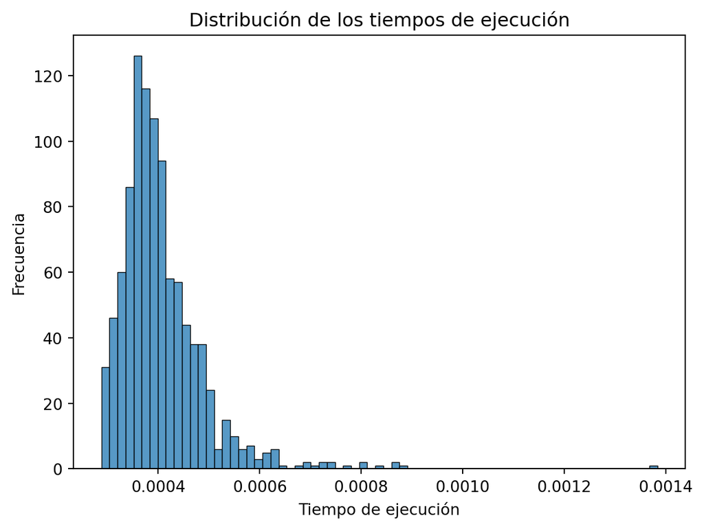

```python
peces_kmeans.plot_comportamiento_tiempos()
```

El tiempo de ejecución presenta una mayor cantidad de valores superiores a los mostrados en el ejemplo anterior en general.

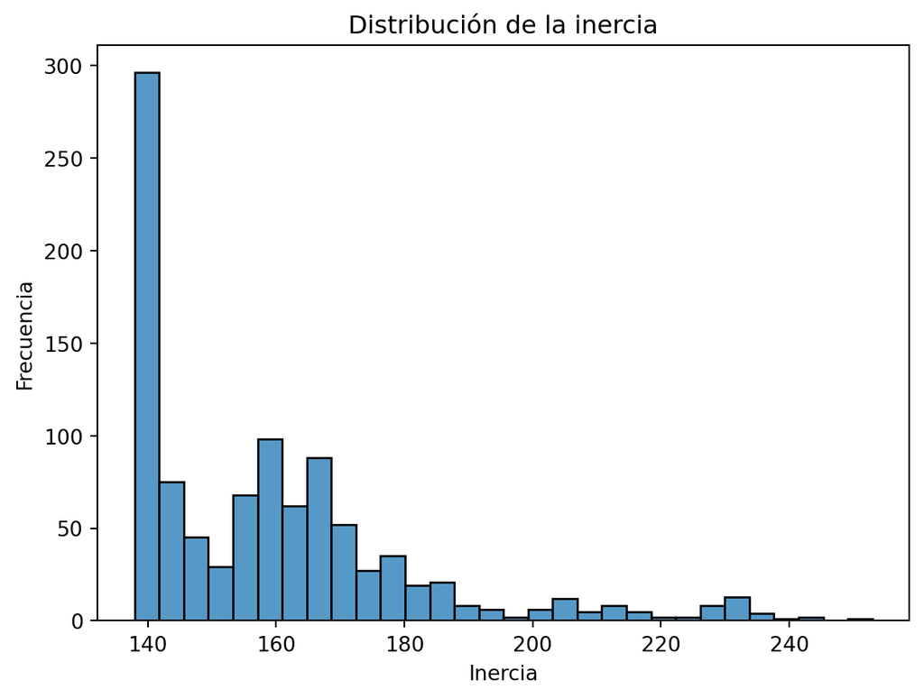

```python
peces_kmeans.plot_comportamiento_locales()
```

```python
peces_ms_4["iteraciones_promedio"]
```

```
3.985
```

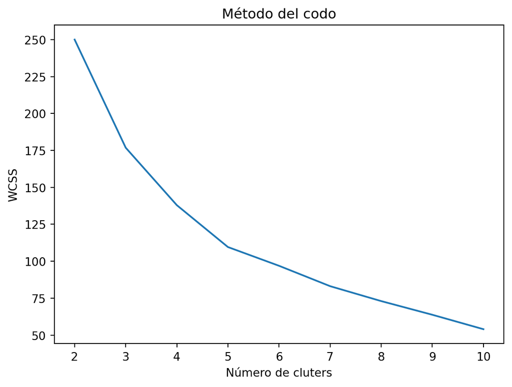

```python
peces_kmeans.elbow()
```

## Iris

```python
from sklearn import datasets

iris = datasets.load_iris()
iris = pd.DataFrame(data= np.c_[iris['data'], iris['target']],columns= iris['feature_names'] + ['target'])
```

```python
iris_kmeans = ej1(iris.drop(["target"], axis = 1))
```

### 3 cluster

Hacemos el multistart con 3 clases

```python
iris_ms_3 = iris_kmeans.kmeans_multistart(3, 1000)
```

```python
iris_ms_3["mejor_inercia"]
```

```
139.82049635974982
```

```python
iris_ms_3["tau"]
```

```
11.200000000000001
```

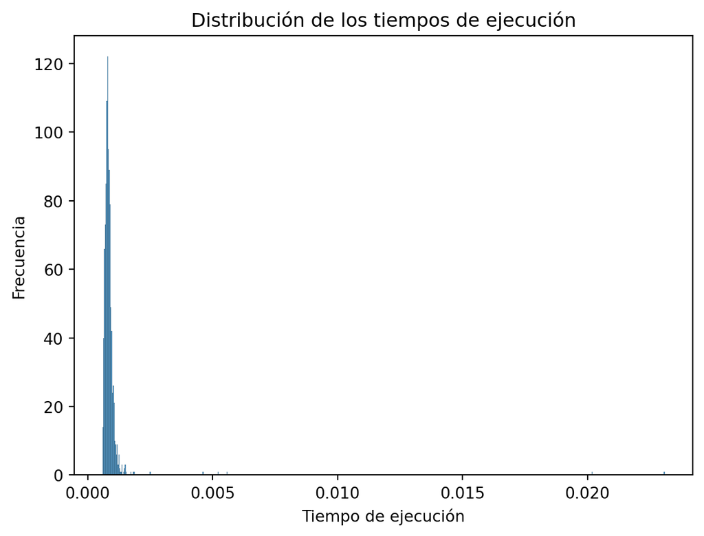

```python
iris_kmeans.plot_comportamiento_tiempos()
```

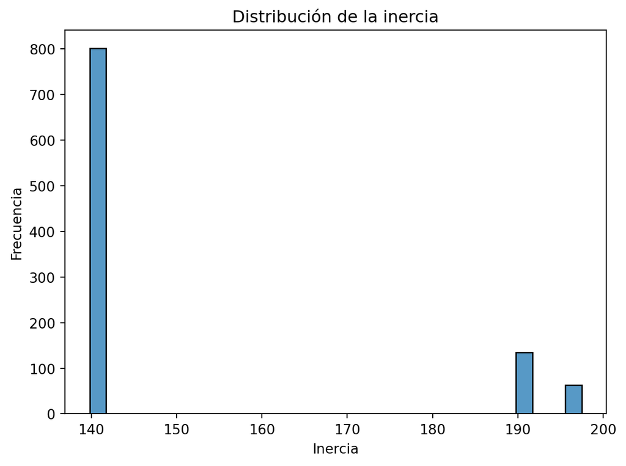

```python
iris_kmeans.plot_comportamiento_locales()
```

Se puede observar que la mayoría de los óptimo se ubican alrededor de 140.

```python
iris_ms_3["iteraciones_promedio"]
```

```
6.281
```

### 4 cluster

Hacemos el multistart con 4 clases

```python
iris_ms_4 = iris_kmeans.kmeans_multistart(4, 1000)
```

```python
iris_ms_4["mejor_inercia"]
```

```
114.09223843568273
```

La inercia mejora como es de esperarse.

```python
iris_ms_4["tau"]
```

```
0.7000000000000001
```

Vemos que en este caso la tasa de atracción disminuye.

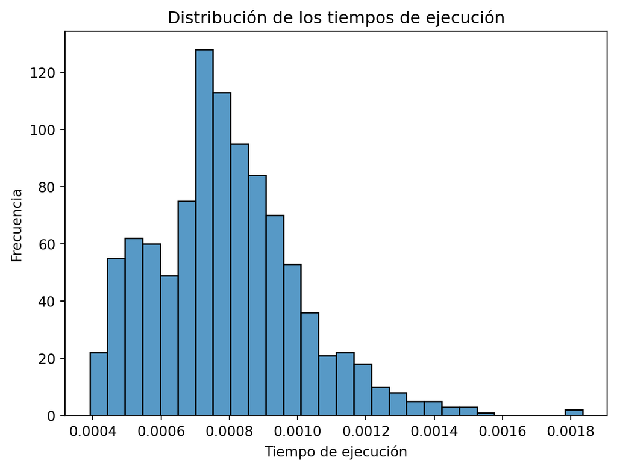

```python
iris_kmeans.plot_comportamiento_tiempos()
```

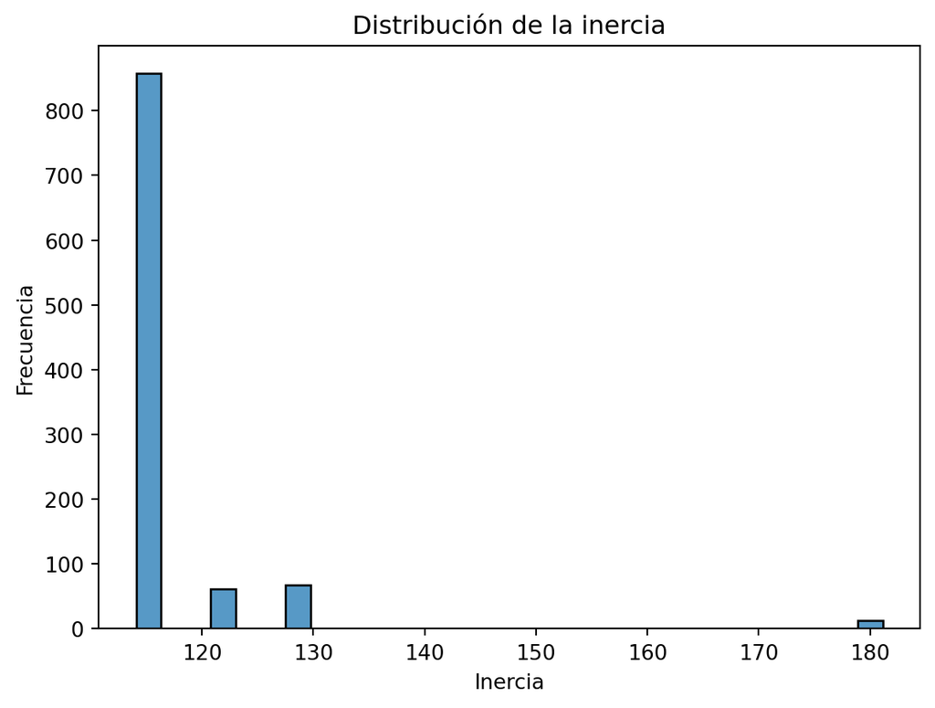

```python
iris_kmeans.plot_comportamiento_locales()
```

```python
iris_ms_4["iteraciones_promedio"]
```

```
8.867
```

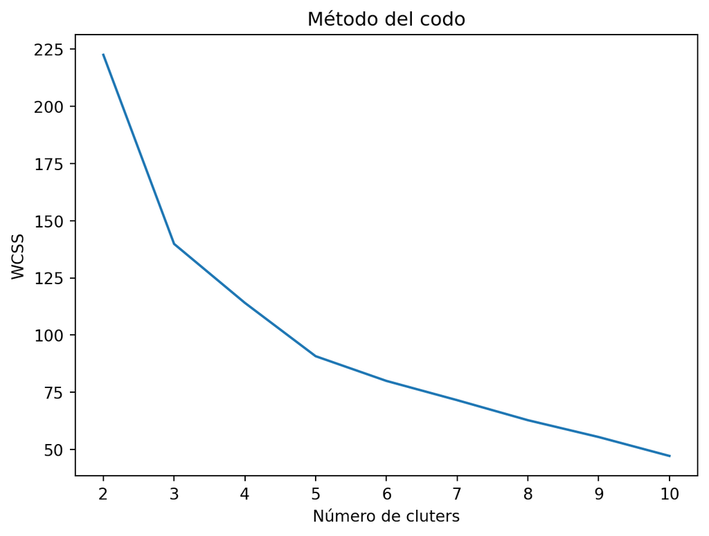

```python
iris_kmeans.elbow()
```

En este caso el número de iteraciones aumenta.

# Ejercicio 2

```python
from scipy.cluster.hierarchy import dendrogram #Para hacer el dendongram

from sklearn.cluster import AgglomerativeClustering #Esto permite hace clusterizacion jerarquica

from cod.ejercicio import plot_dendrogram
```

## Estudiante

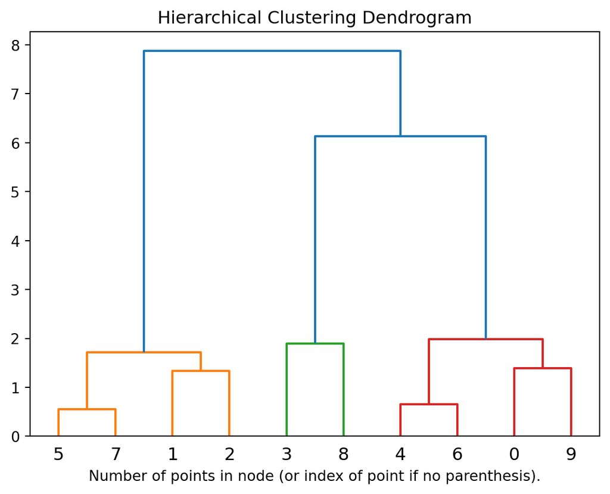

```python
mdl_iris_agg = AgglomerativeClustering(distance_threshold=0, n_clusters=None)


mdl_iris_agg = mdl_iris_agg.fit(df_notas.drop(["Estudiante"], axis = 1))

plt.title("Hierarchical Clustering Dendrogram")
# plot the top three levels of the dendrogram
plot_dendrogram(mdl_iris_agg, truncate_mode="level", p=3)
plt.xlabel("Number of points in node (or index of point if no parenthesis).")
plt.show()
```

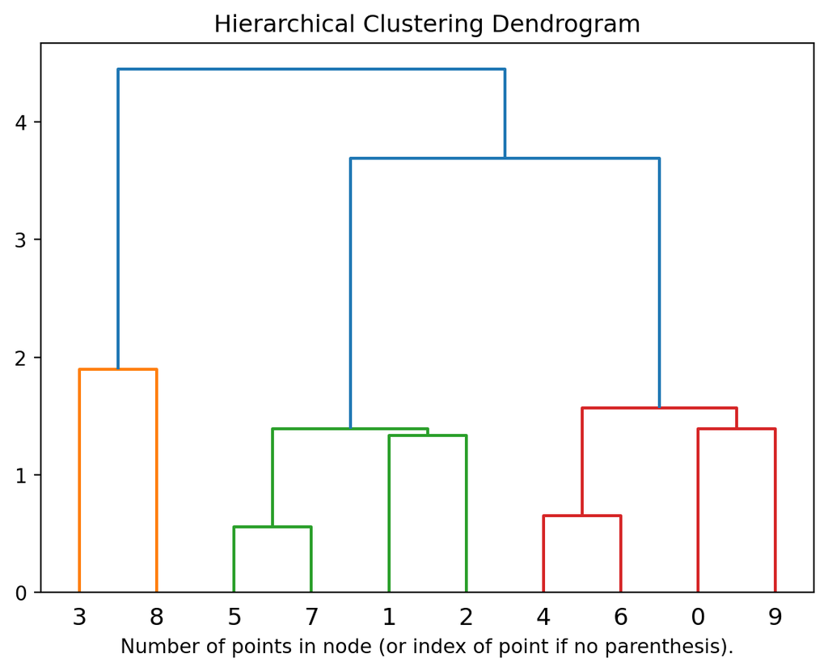

```python
mdl_iris_agg = AgglomerativeClustering(distance_threshold=0, n_clusters=None, linkage="average")


mdl_iris_agg = mdl_iris_agg.fit(df_notas.drop(["Estudiante"], axis = 1))

plt.title("Hierarchical Clustering Dendrogram")
# plot the top three levels of the dendrogram
plot_dendrogram(mdl_iris_agg, truncate_mode="level", p=3)
plt.xlabel("Number of points in node (or index of point if no parenthesis).")
plt.show()
```

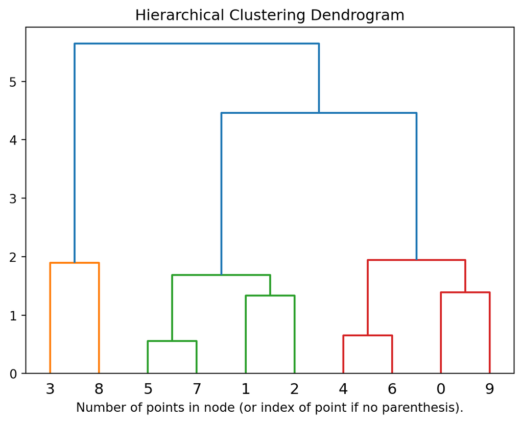

```python
mdl_iris_agg = AgglomerativeClustering(distance_threshold=0, n_clusters=None, linkage="complete")


mdl_iris_agg = mdl_iris_agg.fit(df_notas.drop(["Estudiante"], axis = 1))

plt.title("Hierarchical Clustering Dendrogram")
# plot the top three levels of the dendrogram
plot_dendrogram(mdl_iris_agg, truncate_mode="level", p=3)
plt.xlabel("Number of points in node (or index of point if no parenthesis).")
plt.show()
```